# Şarap kalitesi verisi ile regresyon modellerinin performanslarının kıyaslanması

Öğrenci: Fatih Ekici

Öğretim Görevlisi: Deniz İnan

27 Ocak 2021

Abstract

Bu döküman Doç.Dr. Deniz İnan tarafından verilen IST4034.1 kodlu Veri Madenciliği dersi finali için hazırlanmıştır. Veri kaynağı: [UCİ](https://archive.ics.uci.edu/ml/datasets/wine+quality)

# Veri yükleme ve ön işlemleri

**Kullanılan kütüphaneler**

```r
library(readr)
library(caret)
library(rpart)
library(randomForest)
library(gbm)
library(tidyverse)
library(tidymodels)
library(janitor)
```

**Verinin okutulması**

```r
wine_df<-read.csv("winequalityN.csv")
```

```r
glimpse(wine_df)
```

Rows: 6,497 Columns: 13 $ type “white”, “white”, “white”, “white”, “white”, "… $ fixed.acidity 7.0, 6.3, 8.1, 7.2, 7.2, 8.1, 6.2, 7.0, 6.3, 8… $ volatile.acidity 0.27, 0.30, 0.28, 0.23, 0.23, 0.28, 0.32, 0.27… $ citric.acid 0.36, 0.34, 0.40, 0.32, 0.32, 0.40, 0.16, 0.36… $ residual.sugar 20.70, 1.60, 6.90, 8.50, 8.50, 6.90, 7.00, 20…. $ chlorides 0.045, 0.049, 0.050, 0.058, 0.058, 0.050, 0.04… $ free.sulfur.dioxide 45, 14, 30, 47, 47, 30, 30, 45, 14, 28, 11, 17… $ total.sulfur.dioxide 170, 132, 97, 186, 186, 97, 136, 170, 132, 129… $ density 1.0010, 0.9940, 0.9951, 0.9956, 0.9956, 0.9951… $ pH 3.00, 3.30, 3.26, 3.19, 3.19, 3.26, 3.18, 3.00… $ sulphates 0.45, 0.49, 0.44, 0.40, 0.40, 0.44, 0.47, 0.45… $ alcohol 8.8, 9.5, 10.1, 9.9, 9.9, 10.1, 9.6, 8.8, 9.5,… $ quality 6, 6, 6, 6, 6, 6, 6, 6, 6, 6, 5, 5, 5, 7, 5, 7…

1 kategorik 12 numerik değişkenimz var. Güzel type değişkenini one-hot encode ile ayıralım eksik veri varsa onlarla ilgilenelim ve hızlıca model oluşturalım.

```r
sum(is.na(wine_df))
```

[1] 38

6.497 adet gözlem varken doldurmaya gerek yok direk silelim 38 eksik değişkeni.

```r
wine_df<-na.omit(wine_df)
```

Bu işlemler bitince prep ile bir recipe nesnesi oluşuracağım.recipe’ı veriye uygulamak için ise juice fonksiyonunu kullanacağım.Test verimiz içinse bake’i kullanacağız.

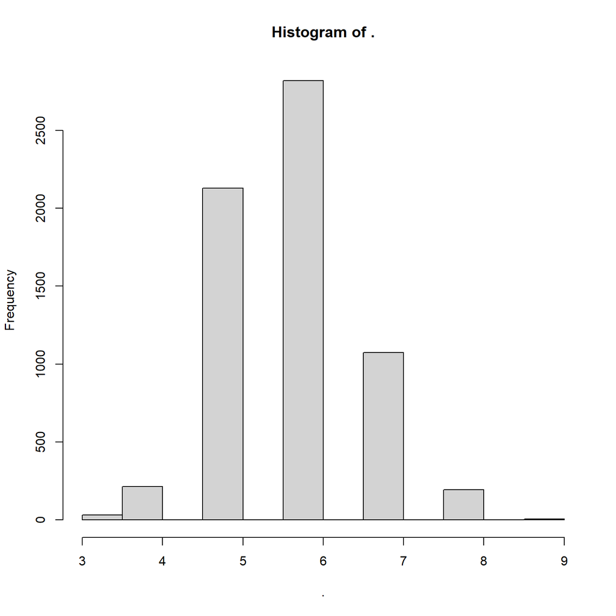

```r
wine_df$quality %>% hist()
```

hedef değişken normal dağılıyor.Eğer dağılmasaydı bazı dönüşüm işlemleri yapabilirdik.

Burada tidymodels ile pre-procesing işlemlerini yapmayı deneyeceğim. Burada birkaç ön işleme adımı uygulayacağız. Verilerimiz için bir EDA yapmadığımız için bunlar biraz geneldir. Yine, bunun amacı, bu veriler için gerçekten harika bir model oluşturmaktan ziyade, bir tidymodels iş akışı hakkında fikir edinmek. Bu adımlarda şunları yapacağız:

1. String değişkenleri faktöre çevir
2. Sıfıra yakın varyans belirleyecilerini kaldırma
3. Factorleri one-hot encode ile yok et
4. tüm sayısal değişkenleri ortalamasına ortalama(verideki type hariç tüm değişkenler)
5. Tüm sayısal tahminleyicileri normalize et

# Veri işleme

## Train Test ayrımı

0.8,-0.20 olarak bölüyoruz.

```r
library(caTools)
# Train-test ayrımı
set.seed(5)
split = sample.split(wine_df$quality, SplitRatio = 0.80)
train = subset(wine_df,split == TRUE)
test = subset(wine_df,split == FALSE)
```

```r
preprocess_recipe <- wine_df %>%
  recipe(quality ~ .) %>%
  step_string2factor(all_nominal()) %>% #this converts all of our strings to factors
  step_other(all_nominal(), threshold = .05) %>% #this will pool infrequent factors into an "other" category
  step_nzv(all_predictors()) %>% #this will remove zero or near-zero variance predictors
  #this will dummy out all factor variables
    step_dummy(all_nominal()) %>%
  step_center(all_numeric(), -all_outcomes()) %>% #this will mean-center all of our numeric data
  step_scale(all_numeric(), -all_outcomes()) %>% #this will normalize numeric data
  prep()

preprocess_recipe
```

Data Recipe

Inputs:

```
  role #variables
```

outcome 1 predictor 12

Training data contained 6463 data points and no missing data.

Operations:

Factor variables from type [trained] No factor levels were collapsed Sparse, unbalanced variable filter removed no terms [trained] Dummy variables from type [trained] Centering for fixed.acidity, volatile.acidity, … [trained] Scaling for fixed.acidity, volatile.acidity, … [trained]

preprocess nesnemiz oluştu train ve test verilerine uygulayalım. Bu kısımda recipe işlemini workflow’a dahil ediyorum model oluştururken workflow üzerinden gerekeni uygulatabiliriz. Bazı durumlarda ise preprocess edilmiş veriyi kullanmak daha uygun olacaktır.

```r
 train_prep <- juice(preprocess_recipe)
 test_prep <- preprocess_recipe %>%
   bake(test)
 head(train_prep)
```

| fixed.acidity | volatile.acidity | citric.acid | residual.sugar | chlorides | free.sulfur.dioxide | total.sulfur.dioxide | density | pH | sulphates | alcohol | quality | type_white |
| --- | --- | --- | --- | --- | --- | --- | --- | --- | --- | --- | --- | --- |
| -0.16777311 | -0.4226769 | 0.283936734 | 3.2071721 | -0.31520317 | 0.81554622 | 0.9607048 | 2.0997638 | -1.3590550 | -0.5449450 | -1.4188125 | 6 | 0.5718864 |
| -0.70710045 | -0.2404603 | 0.146245260 | -0.8080887 | -0.20116451 | -0.93006570 | 0.2884566 | -0.2324473 | 0.5083598 | -0.2763325 | -0.8321195 | 6 | 0.5718864 |
| 0.67974128 | -0.3619380 | 0.559319680 | 0.3060936 | -0.17265485 | -0.02910471 | -0.3307195 | 0.1340430 | 0.2593712 | -0.6120982 | -0.3292398 | 6 | 0.5718864 |
| -0.01367959 | -0.6656323 | 0.008553787 | 0.6424506 | 0.05542247 | 0.92816634 | 1.2437567 | 0.3006295 | -0.1763589 | -0.8807106 | -0.4968664 | 6 | 0.5718864 |
| -0.01367959 | -0.6656323 | 0.008553787 | 0.6424506 | 0.05542247 | 0.92816634 | 1.2437567 | 0.3006295 | -0.1763589 | -0.8807106 | -0.4968664 | 6 | 0.5718864 |
| 0.67974128 | -0.3619380 | 0.559319680 | 0.3060936 | -0.17265485 | -0.02910471 | -0.3307195 | 0.1340430 | 0.2593712 | -0.6120982 | -0.3292398 | 6 | 0.5718864 |

```r
wine_wf <- workflow() %>%
  add_recipe(preprocess_recipe)
```

Verimiz temizlendi model oluşturmaya geçebiliriz.

# Modelleme

Bu kısımda artık modelleri oluşturmaya başlayabiliriz.

# Bagging Regression

Bu kısımda model oluştururken tidymodels’ın daha esnek ve basit model kurma aracını kullanıyoruz.

```r
library(baguette)

wine_spec <- bag_mars() %>% #bagged mars model fonksiyonu
  set_engine("earth", times = 25) %>% #paket
  set_mode("regression") #classifier mi regresyon mu?

wine_spec
```

Bagged MARS Model Specification (regression)

Engine-Specific Arguments: times = 25

Computational engine: earth

Burada görüldüğü üzere model spec’i ni oluşturdum. Şimdi model nesnesini oluşturalım.

```r
Model_Bagged <-wine_wf %>%
  add_model(wine_spec) %>%
  fit(train)

Model_Bagged$fit$fit
```

parsnip model object

Fit time: 6s Bagged MARS (regression with 25 members)

Variable importance scores include:

# A tibble: 11 x 4

term value std.error used 1 alcohol 100 0 25 2 volatile.acidity 63.2 0.285 25 3 free.sulfur.dioxide 43.7 0.958 25 4 total.sulfur.dioxide 38.2 0.922 25 5 sulphates 37.0 1.31 25 6 residual.sugar 29.3 0.856 25 7 density 15.6 0.981 19 8 citric.acid 10.9 1.41 18 9 chlorides 5.79 0.695 7 10 pH 5.73 1.32 11 11 fixed.acidity 2.09 0.819 4

Değişkenlerin importance değerleri.

## Model performasını ölçelim.

Nodel performansı için yine predict fonksiyonunu kullanıyoruz. Daha sonrada metrics ile sonuçları alabiliriz.

```r
baging_test <- test %>%
  bind_cols(predict(Model_Bagged, test)) %>%

  rename(.pred_quality = .pred)

baging_test  %>%
  metrics(quality, .pred_quality) %>% mutate(model_type="Bagging")->resultBag

resultBag
```

| .metric | .estimator | .estimate | model_type |
| --- | --- | --- | --- |
| rmse | standard | 0.7094271 | Bagging |
| rsq | standard | 0.3397759 | Bagging |
| mae | standard | 0.5556622 | Bagging |

# Random Forest

Model nesnemizi oluşturalım.

```r
rf_xy_fit<-
  rand_forest(mode="regression") %>% set_engine("ranger") %>%
  fit_xy(
    x=select(train_prep,-quality),
    y=train_prep$quality
  )

rf_xy_fit # parsnip paketinden random forest modeli oluşturuldu.
```

parsnip model object

Fit time: 2.8s Ranger result

Call: ranger::ranger(x = maybe_data_frame(x), y = y, num.threads = 1, verbose = FALSE, seed = sample.int(10^5, 1))

Type: Regression Number of trees: 500 Sample size: 6463 Number of independent variables: 12 Mtry: 3 Target node size: 5 Variable importance mode: none Splitrule: variance OOB prediction error (MSE): 0.3387249 R squared (OOB): 0.5558456

mtr değeri 3 node sayısı 5 olan bir modelimiz oluştu. Açıkçası pek başarılı durmuyor yinede modeli test verisi üzerinde deneyerek nihai yargıya varalım.

```r
test_results <-
  test_prep %>%
  select(quality) %>%
  bind_cols(
    predict(rf_xy_fit, new_data = test_prep)
  )
```

Predict sonuçlarını aldık metrikler üzerindeki sonuçlarını gösterelim.

```r
test_results %>% metrics(truth = quality, estimate = .pred) %>% mutate(model_type="Random Forest")-> resultRF
```

Random forest oldukça iyi bir sonuç bulduk, ~0.25 rmse değeri bu değerin oldukça iyi bir sonuç olduğunu söyleyebiliriz.

# Boosting regresyon

Boosting için tidymodelsda xgboost motorunu kullanabiliyoruz, Bu model hakkında yeterli bilgi bulamadım bu sebeble caret ile kuracağım.

# GBM

## Model

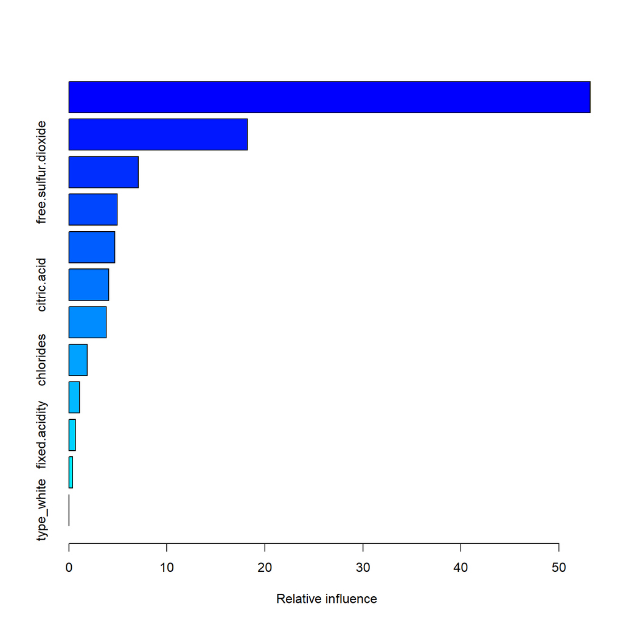

|  | var | rel.inf |
| --- | --- | --- |
| alcohol | alcohol | 53.1930583 |
| volatile.acidity | volatile.acidity | 18.2065031 |
| free.sulfur.dioxide | free.sulfur.dioxide | 7.0683438 |
| residual.sugar | residual.sugar | 4.9355776 |
| sulphates | sulphates | 4.6945839 |
| citric.acid | citric.acid | 4.0767020 |
| total.sulfur.dioxide | total.sulfur.dioxide | 3.8114692 |
| chlorides | chlorides | 1.8709945 |
| pH | pH | 1.0890413 |
| fixed.acidity | fixed.acidity | 0.6878169 |

[output cut: 2 more lines]

```r
gbm_fit <- gbm(quality ~ ., data = train_prep ,
    distribution = "gaussian",
    n.trees = 2000,
    interaction.depth = 1,
    shrinkage = 0.01,
    cv.folds = 5)

summary(gbm_fit)
```

Daha önceki modellerde gördüğümüz üzere en çok etki eden değişken alkol değişkeni Kalan değişkenlerin ağırlıkları daha düşük.

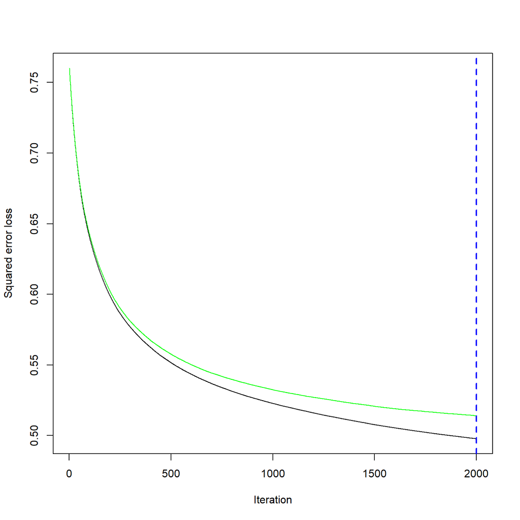

```r
gbm.perf(gbm_fit, method = "cv")
```

[1] 2000

```r
defaultSummary(data.frame(obs = train_prep$quality,
                            pred = gbm_fit$fit))
```

```
 RMSE  Rsquared       MAE
```

0.7054724 0.3510047 0.5544358

Modelin train performansı çok yüksek değil train sonucuna bakıp modelleri kıyaslamaya geçebiliriz.

## Tahmin

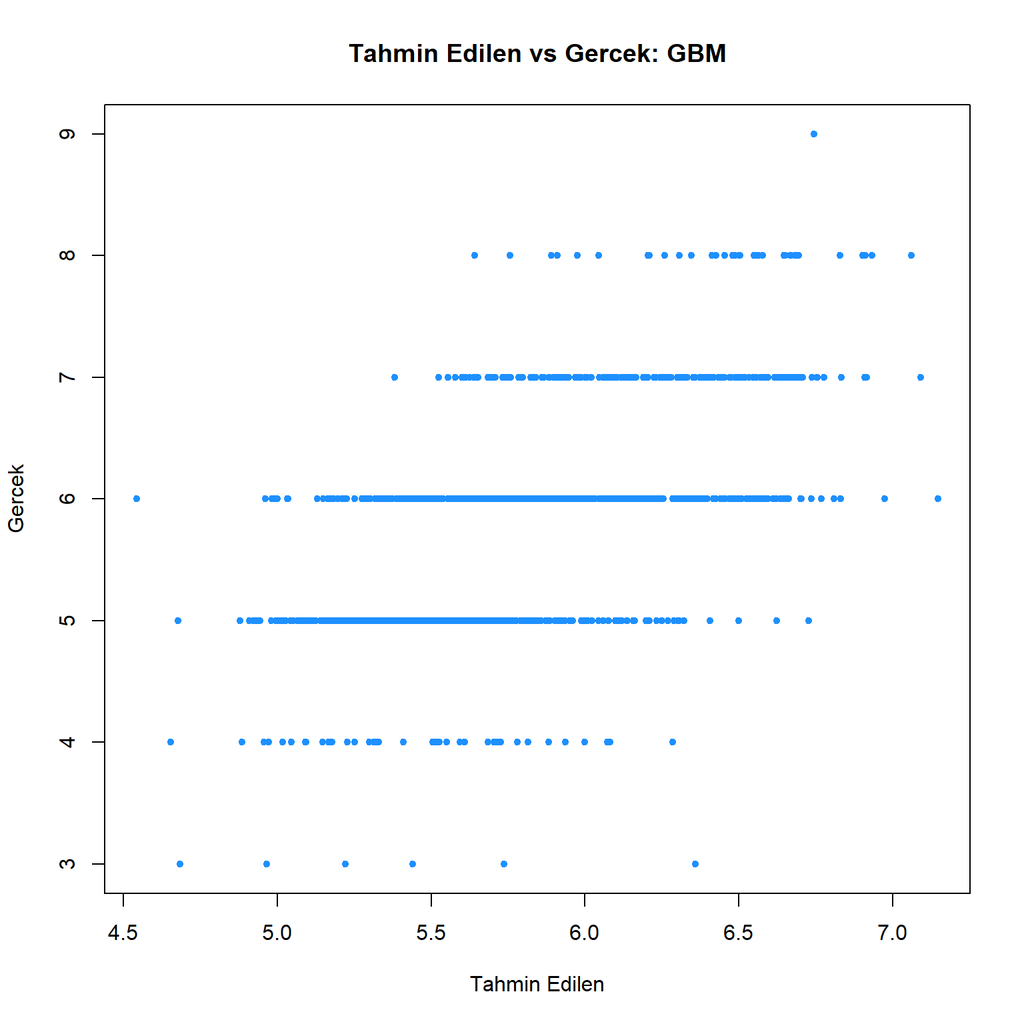

```r
defaultSummary(data.frame(obs = test_prep$quality,
                            pred = predict(gbm_fit,
                                           select(test_prep,-quality),
                                           n.trees = 2000)))->resultGBM


plot(predict(gbm_fit, select(test_prep,-quality), n.trees = 5000), test_prep$quality,
     xlab = "Tahmin Edilen", ylab = "Gercek",
     main = "Tahmin Edilen vs Gercek: GBM",
     col = "dodgerblue", pch = 20)
```

```r
resultGBM
```

```
 RMSE  Rsquared       MAE
```

0.7031052 0.3568169 0.5545133

# Model Sonuçları kıyaslama

```r
data.frame(Modeller=c("Bagging","GBM","Random Forest"),
           RMSE=c(
resultBag$.estimate[1],
resultGBM[[1]],
resultRF$.estimate[1]))->sonuc

sonuc
```

| Modeller | RMSE |
| --- | --- |
| Bagging | 0.7094271 |
| GBM | 0.7031052 |
| Random Forest | 0.2589063 |

En iyi sonucu Random Forest ile aldık. Bagging ve GBM oldukça yakın sonuçlar verdi.